# Food Orders Prep Time Prediction

## Intro

QuickFood is committed to providing a delivery experience that delights its customers while still being incredibly efficient. Thus it is critical that it has the best possible model of the length of time it takes for a food order to be prepared. This allows QuickFood to ensure that a rider arrives at a restaurant to pick up an order exactly when the food is ready. The aim of this exercise is therefore to use historical data to predict food preparation time for each order.

## Data Visualisation

Visualising the distributions of variables is a helpful first step, particularly to choose the best type of model for the kind of data we’re working with. We first merge the “orders” and “restaurants” data sets into one table. A summary of the data follows:

```r
# read and join data

restaurants <- read_csv("algos-takehome/restaurants.csv.gz")
orders <- read_csv("algos-takehome/orders.csv.gz")

allData <- orders %>%
  left_join(restaurants, by = "restaurant_id")

# filter outliers and create time vars for visualisation
allData <- allData %>%
  mutate(
    weekday = wday(order_acknowledged_at),
    order_time_sec = as.numeric(as.duration(hms::as_hms(
      order_acknowledged_at
    ))),
    week = week(order_acknowledged_at)
  )

vizData <- allData %>%
  filter(
    number_of_items < sum(mean(number_of_items), sd(number_of_items)),
    prep_time_seconds < sum(mean(prep_time_seconds), sd(prep_time_seconds)),
    order_value_gbp < sum(mean(order_value_gbp), sd(order_value_gbp))
  ) %>%
  group_by(type_of_food) %>%
  mutate(freq = n()) %>%
  filter(freq > 100) %>%
  ungroup

# show data
glimpse(vizData)
```

```
## Rows: 26,008
## Columns: 13
## $ order_acknowledged_at <dttm> 2015-06-08 13:56:15, 2015-06-01 20:01:37, 2015…
## $ order_ready_at        <dttm> 2015-06-08 14:03:39, 2015-06-01 20:19:07, 2015…
## $ order_value_gbp       <dbl> 15.25, 18.20, 43.20, 35.80, 30.00, 16.00, 17.40…
## $ restaurant_id         <dbl> 1326, 255, 255, 255, 255, 255, 255, 255, 255, 2…
## $ number_of_items       <dbl> 3, 3, 4, 4, 3, 1, 3, 3, 3, 3, 3, 3, 3, 3, 3, 4,…
## $ prep_time_seconds     <dbl> 443, 1049, 1468, 1300, 1254, 1801, 640, 1072, 6…
## $ country               <chr> "UK", "UK", "UK", "UK", "UK", "UK", "UK", "UK",…
## $ city                  <chr> "London", "London", "London", "London", "London…
## $ type_of_food          <chr> "burritos", "chinese", "chinese", "chinese", "c…
## $ weekday               <dbl> 2, 2, 2, 2, 2, 4, 7, 2, 2, 2, 2, 3, 3, 4, 7, 7,…
## $ order_time_sec        <dbl> 50175.50, 72097.82, 72276.20, 74854.35, 76311.4…
## $ week                  <dbl> 23, 22, 22, 22, 22, 22, 23, 23, 23, 23, 23, 23,…
## $ freq                  <int> 311, 977, 977, 977, 977, 977, 977, 977, 977, 97…
```

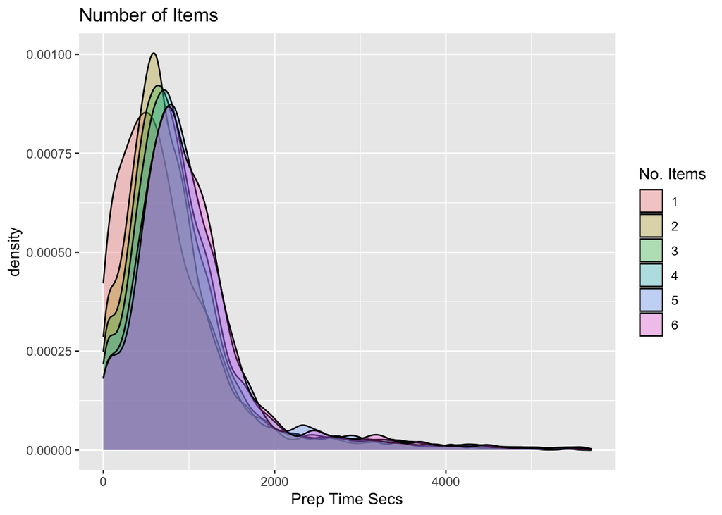

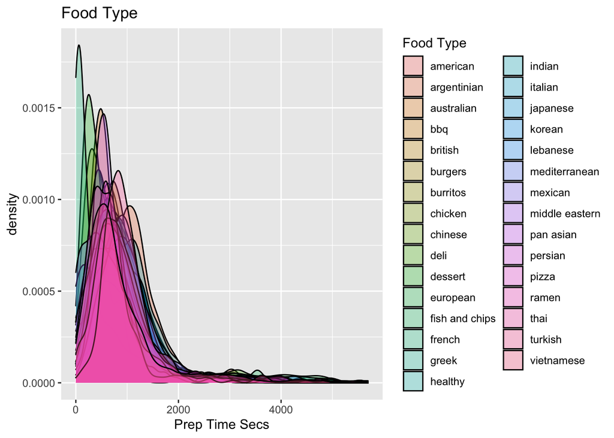

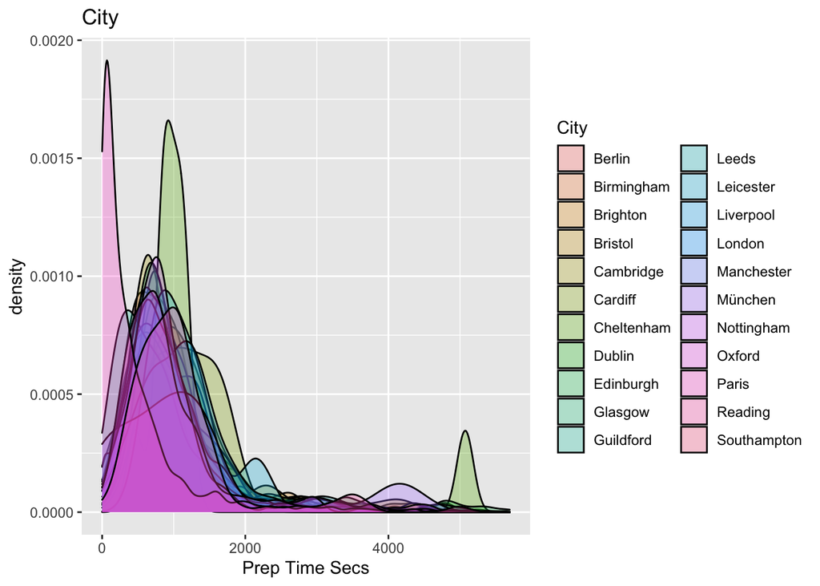

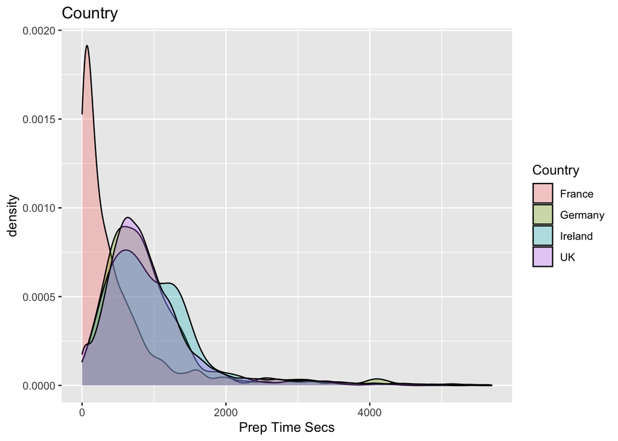

```r
par(mar = c(2, 2, .1, .1))

# visualise prep_time_seconds against other vars

ggplot(data = vizData) + geom_density(aes(x = prep_time_seconds, fill = factor(number_of_items)),
                                      position = "identity",
                                      alpha = 0.3) + labs(fill = "No. Items",
                                                          x = "Prep Time Secs",
                                                          title = "Number of Items")

ggplot(data = vizData) + geom_density(aes(x = prep_time_seconds,  fill = factor(type_of_food)),
                                      position = "identity",
                                      alpha = 0.3) + labs(fill = "Food Type",
                                                          x = "Prep Time Secs",
                                                          title = "Food Type")

ggplot(data = vizData) + geom_density(aes(x = prep_time_seconds, fill = factor(city)),
                                      position = "identity",
                                      alpha = 0.3) + labs(fill = "City",
                                                          x = "Prep Time Secs",
                                                          title = "City")

ggplot(data = vizData) + geom_density(aes(x = prep_time_seconds,
                                          fill = factor(country)),
                                      position = "identity",
                                      alpha = 0.3) + labs(fill = "Country",
                                                          x = "Prep Time Secs",
                                                          title = "Country")
```

Average preparation times vary by country, city and food type. Preparation times of orders with a different number of items in them do not vary as much. The main intuition to take away is that food preparation time is a function of the interactions of various geographical, cultural and culinary determining factors.

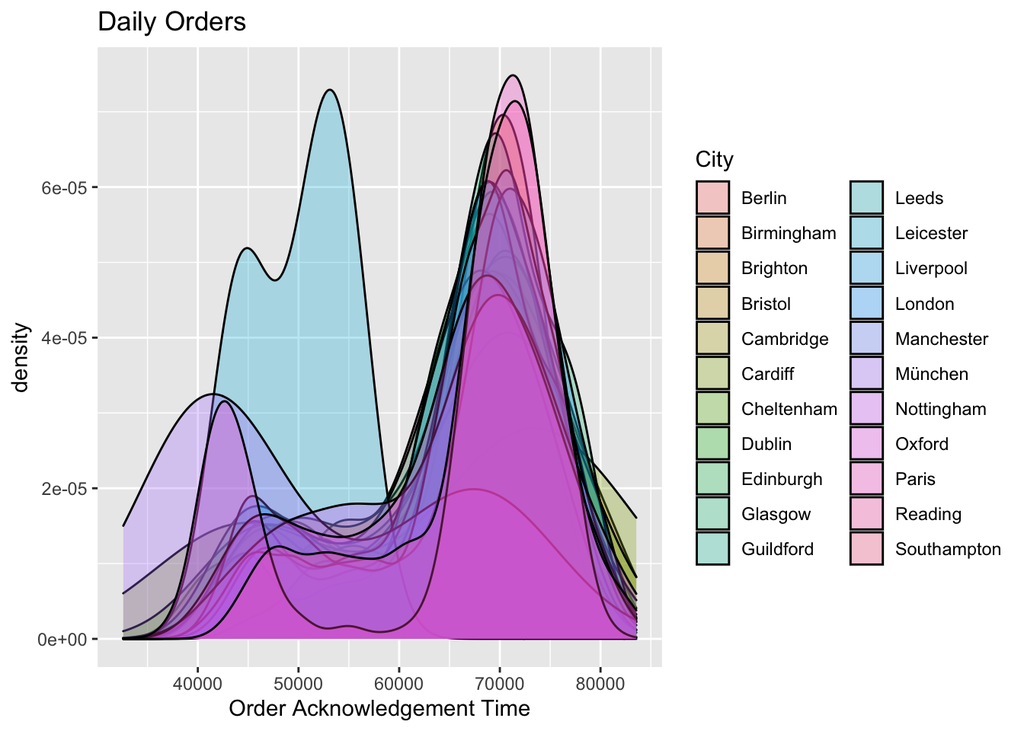

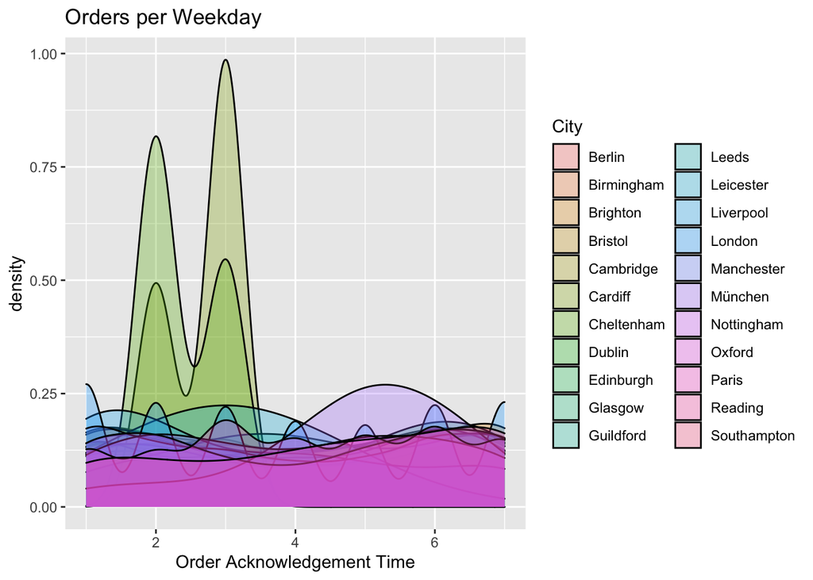

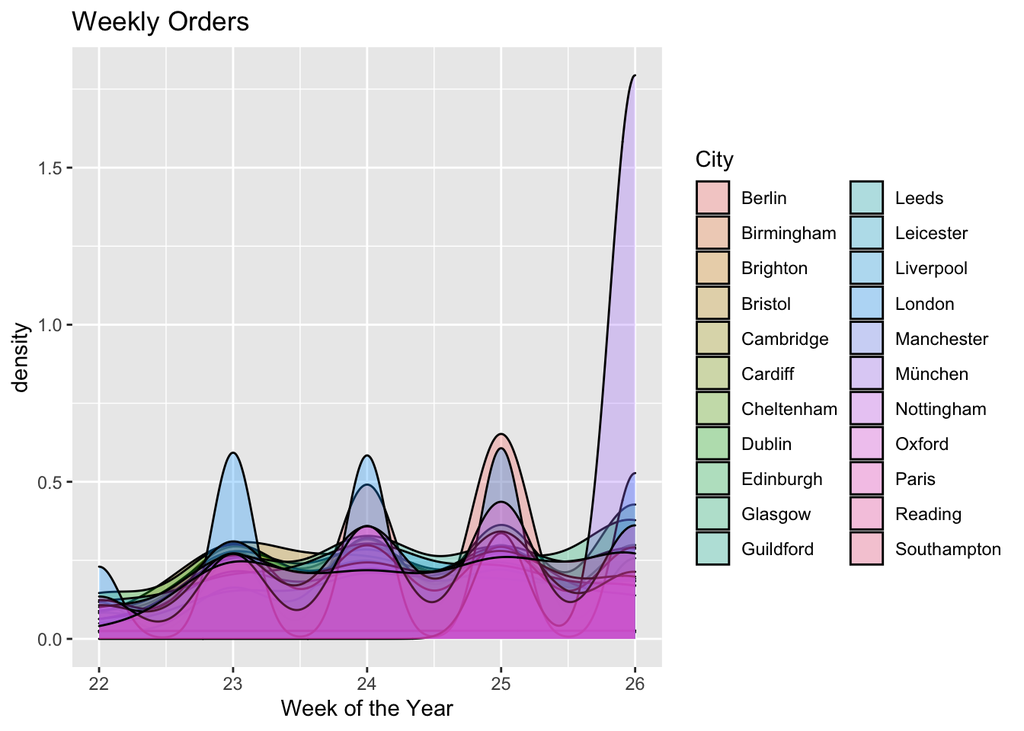

```r
par(mar = c(2, 2, .1, .1))

ggplot(data = vizData) + geom_density(aes(x = order_time_sec,
                                          fill = factor(city)),
                                      position = "identity",
                                      alpha = 0.3) + labs(fill = "City",
                                                          x = "Order Acknowledgement Time",
                                                          title = "Daily Orders")

ggplot(data = vizData) + geom_density(aes(x = weekday,
                                          fill = factor(city)),
                                      position = "identity",
                                      alpha = 0.3) + labs(fill = "City",
                                                          x = "Order Acknowledgement Time",
                                                          title = "Orders per Weekday")

ggplot(data = vizData) + geom_density(aes(x = week,
                                          fill = factor(city)),
                                      position = "identity",
                                      alpha = 0.3) + labs(fill = "City",
                                                          x = "Week of the Year",
                                                          title = "Weekly Orders")
```

Factors like number of staff members or efficiency practices of the restaurant may impact significantly preparation times. If a restaurant were quite prepared for busy Saturday nights, it would perhaps take less time to get orders ready than during Tuesday at lunch time. Although this information may be somewhat captured by time variables, more information about restaurants like number of staff members or ratio of capacity allocated to takeaway orders may be valuable information to predict how long in average will it take for a restaurant to have its orders ready.

The distributions of most the above variables are unimodal and skewed to the right but some variables are bimodal or multimodal (e.g. Weekday). It follows that a linear model wouldn’t be the best approach to predict prep times. Further, a robust model ought to capture interactions between most of these variables and not just between pairs. For these reasons an adequate type of model for this regression problem may be a tree model or a neural network with two or more hidden layers.

## Data Preprocessing

Certain variables were kept as is. Categorical variables were one-hot encoded and numeric variables were rescaled with mean zero and standard deviation of one. Outliers were kept for model building.

```r
# select relevant variables, dummify categoricals, rescale numerics
allData <- allData %>%
  dplyr::select(
    order_value_gbp,
    number_of_items,
    country,
    city,
    type_of_food,
    weekday,
    order_time_sec,
    week
  ) %>%
  dummy_cols(
    select_columns = c("country",
                       "city",
                       "type_of_food",
                       "weekday",
                       "week"),
    remove_first_dummy = T,
    remove_selected_columns = T
  ) %>%
  mutate(across(all_of(
    c("order_value_gbp",
      "number_of_items",
      "order_time_sec")
  ),
  ~ psych::rescale(.,
                   mean = 0,
                   sd = 1)))
```

## Model

The data was split randomly into training and validation sets at a 70-30 proportion respectively. A neural network was trained using Tensorflow/Keras API and tested on the validation sample. In future iterations perhaps a stratification of the split could be explored by country, city and even food type to make sure the model performs equally across segments.

The architecture of the sequential neural network that was built has two hidden layers with 256 units each and a third layer with one unit which outputs the final prediction. This architecture was arrived at iteratively but motivated by the multimodality of the distributions of the density probabilities of some variables which suggests that non-linear relations between features and preparation time may exist. Elastic net regularisation, batch normalisation as well as dropout were implemented to prevent the model from overfitting the training data. In other words, a relatively simple architecture was used and penalisations were adopted to force the model to become even simpler so that it performs as well (as possible) when scoring new data.

The plots below show the Mean Squared Error (loss) and the Mean Absolute Error (evaluation metric) fall quite evenly on the training and validation sets as the model continued to train. An adaptive measure to reduce learning rate when the validation loss plateaued was adopted to promote the model converging in the global or at least an acceptable local minima in the validation set. Early stopping was implemented as well to stop the training once the reduction of MSE stagnated.

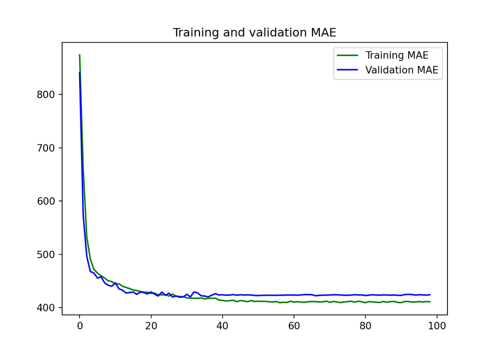

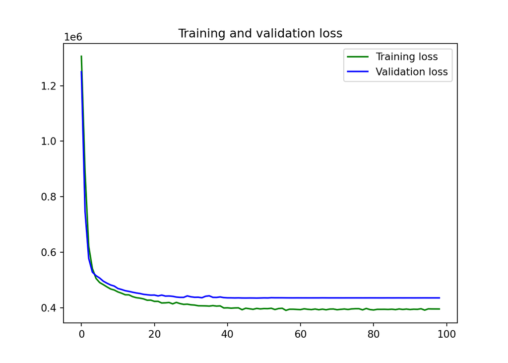

```python
import pandas as pd
import numpy as np
import tensorflow as tf
import math
from sklearn import model_selection as ms
import matplotlib.pyplot as plt
from sklearn.metrics import mean_absolute_error
from sklearn.metrics import mean_squared_error

allData = pd.read_csv("allData.csv")
label = allData["prep_time_seconds"]
allData = allData.drop("prep_time_seconds", axis=1)
x_train, x_test, y_train, y_test = ms.train_test_split(allData, label, test_size=0.3, random_state=123)
x_train, x_test = x_train.to_numpy(), x_test.to_numpy()
x_train, x_test = np.reshape(x_train, (x_train.shape[0],1, x_train.shape[1])), np.reshape(x_test, (x_test.shape[0],1, x_test.shape[1]))

tf.keras.backend.clear_session()
model = tf.keras.Sequential([
        tf.keras.layers.Dense(256, activation='relu', bias_regularizer=tf.keras.regularizers.l1_l2(l1=0.1,l2=0.1), kernel_regularizer=tf.keras.regularizers.l1_l2(l1=0.1,l2=0.1)),
        tf.keras.layers.Dropout(0.5),
        tf.keras.layers.BatchNormalization(),
        tf.keras.layers.Dense(256, activation='relu', bias_regularizer=tf.keras.regularizers.l1_l2(l1=0.1,l2=0.1), kernel_regularizer=tf.keras.regularizers.l1_l2(l1=0.1,l2=0.1)),
        tf.keras.layers.Dense(1)])

cbs = [tf.keras.callbacks.ReduceLROnPlateau(monitor='val_loss', patience=5,verbose=1),
       tf.keras.callbacks.EarlyStopping(monitor="val_loss", patience=50,verbose=1,restore_best_weights=True)]

model.compile(loss="mse",
              optimizer="RMSprop",
              metrics=['mae'])

model_hist = model.fit(x=x_train,
          y=y_train,
          epochs=1000,
          batch_size=200,
          validation_data=(x_test, y_test),
          verbose=1,
          callbacks=[cbs])
```

```python
prediction = pd.DataFrame()
prediction[0] = y_test
prediction[1] = model.predict(x_test).reshape(x_test.shape[0]).astype("int64")
prediction[2]  = abs(prediction[1] - prediction[0])
prediction.columns=['y','y_hat','error']

rmse = math.sqrt(mean_squared_error(prediction.iloc[:,1],prediction.iloc[:,0]))
mae = mean_absolute_error(prediction.iloc[:,1],prediction.iloc[:,0])

print(prediction)
```

```
##           y  y_hat  error
## 8496    499    645    146
## 24367  1226    980    246
## 1071   1191    855    336
## 21846   746    589    157
## 16437   826   1150    324
## ...     ...    ...    ...
## 6380     70    905    835
## 20941   737    830     93
## 1378   2664   1205   1459
## 4126    991   1031     40
## 8696    246    705    459
##
## [7803 rows x 3 columns]
```

```python
print("Root Mean Squared Error = " + str(rmse))
```

```
## Root Mean Squared Error = 658.0703041337013
```

```python
print("Mean Absolute Error = " + str(mae))
```

```
## Mean Absolute Error = 423.6862745098039
```

## Discussion

The Mean Absolute Error on the validation set is about 7 minutes. This is an early indication of this model being a robust first step into predicting preparation time with a consistent average error interval of about 7 minutes even for restaurants for which there is no previous order history. As usual, training on more data would be beneficial to reduce error even further, particularly for some food categories.

Whether 7 minutes of mean error is acceptable is debatable. Whether that is good enough for customers and deliverers is a question that deserves attention. As a customer one would be inclined to say that if food arrives seven minutes before or after, customer experience perhaps is not all that affected. However, does a mean error of 7 minutes translate into inefficient operation in the greater scheme and has this a substantial knock-on effect? These are are questions that deserve investigation in further iterations but also perhaps an informed business-focused call.

Further optimisation of the model could be pursued in terms of error and value of orders. More generally, it would be interesting to explore whether larger errors in predictions occur on orders with specific attributes and what are these. This information would help optimising the model and inform QuickFood’s strategy importantly. Finally, this model must work together with that of orders allocation to deliverers, an interesting optimisation problem indeed.